# STA206_Project

**Similarly, we can check for the RETPLASMA model.**

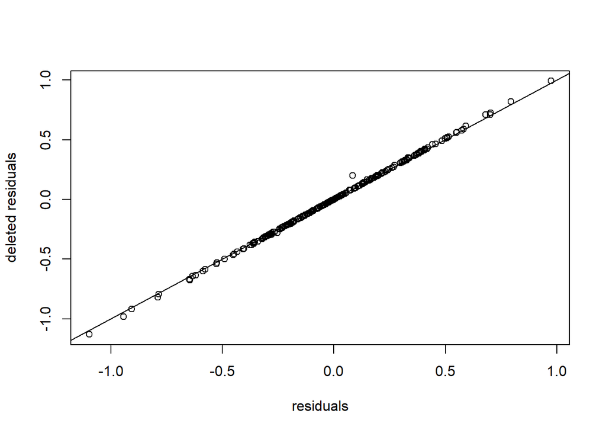

```r
e<-final_model_RETPLASMA$residuals ##ordinary residuals
h<-influence(final_model_RETPLASMA)$hat ##diagonals of the hat matrix: a.k.a. leverage values
de<-e/(1-h) ##deleted residuals
plot(e,de, xlab="residuals", ylab="deleted residuals")
abline(0,1)
```

```r
summary(h)
```

```
##     Min.  1st Qu.   Median     Mean  3rd Qu.     Max.
## 0.008185 0.014151 0.018473 0.023904 0.025803 0.581797
```

```r
#studentized deleted residuals
library(MASS)
stu.res.del <- studres(final_model_RETPLASMA)
head(sort(abs(stu.res.del), decreasing=TRUE))
```

```
##       81      293       75      311      201       62
## 3.569475 3.132820 3.067033 2.899701 2.558553 2.545318
```

```r
stu.res.del <- studres(final_model_RETPLASMA)
head(sort(abs(stu.res.del), decreasing=TRUE))
```

```
##       81      293       75      311      201       62
## 3.569475 3.132820 3.067033 2.899701 2.558553 2.545318
```

```r
# Bonferroni 's Threshold
n = nrow(train_data2)
p = length(coef(final_model_RETPLASMA))
qt(1-0.1/(2*n), n-p-1) #Bonferroni's Threshold (alpha=0.1, n=sample size)
```

```
## [1] 3.590881
```

```r
# checking case which is larger than 2p/n
h <- influence(final_model_RETPLASMA)$hat
p <- length(coef(final_model_RETPLASMA))
sort(h[which(h>2*p/n)], decreasing = TRUE)
```

```
##        309         73        313          3        162         86         27
## 0.58179739 0.09681651 0.09183343 0.08351414 0.05426804 0.05253895 0.05160005
##         40
## 0.05096084
```

```r
# Calculating Cook's distance
res <- final_model_RETPLASMA$residuals
mse <- anova(final_model_RETPLASMA)["Residuals", 3]
cook.d <- res^2*h/(p*mse*(1-h)^2)

# identify influential cases
sort(cook.d[which(cook.d>4/(n-p))], decreasing = TRUE)
```

```
##         75         81         62        309         50        201        296
## 0.06281695 0.06060516 0.03910759 0.03872360 0.03445535 0.03427829 0.03274386
##        293         16         18        235
## 0.02782003 0.02427038 0.02263651 0.02125472
```

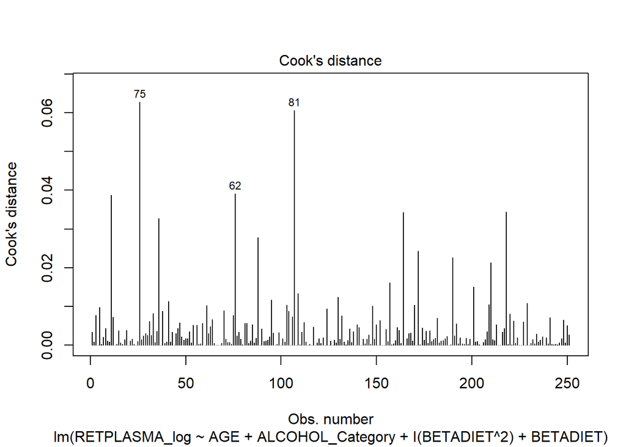

```r
# Cook’s distance plot
plot(final_model_RETPLASMA, which=4)
```

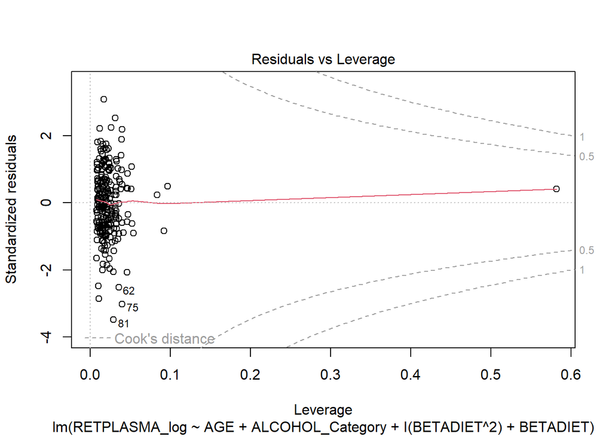

```r
# the Residuals vs. Leverage plot
plot(final_model_RETPLASMA, which=5)
```

Therefore, there is no influencial case in RETPLASMA model.

*Note：*

We noticed that there was a previous data on extreme drinking, and intuitively, this is an influencial case, which we will examine below:

This data is not even outlyer when regression BETAPLASMA_log, focus on whether it is influencial in RETPLASMA_log regression.

Testing

```r
which(rownames(train_data2)=="62")
```

```
## [1] 76
```

```r
fit.62 = lm(RETPLASMA_log ~ AGE + ALCOHOL_Category + I(BETADIET^2) + BETADIET, data = train_data2, subset=setdiff(rownames(train_data2), "62"))

# compare regression coefficients
rbind(final_model_RETPLASMA$coefficients,fit.62$coefficients)
```

```
##      (Intercept)        AGE ALCOHOL_CategoryNormal ALCOHOL_CategoryHeavy
## [1,]    6.248876 0.08777117             0.07838693              0.241762
## [2,]    6.248852 0.09059669             0.08020711              0.267071
##      I(BETADIET^2)    BETADIET
## [1,]    0.03040176 -0.06240995
## [2,]    0.02938232 -0.05960642
```

This case (62 lines in the data), so this data is not an influencial data. Similarly, 75 and 81 are not influencial cases.

# 5. Model Extension

Since we try to investigate the relationship between personal characteristics and two response variables, we want to use model to achieve variable selection. Then, let’s consider the Lasso regression.

## 5-1. Lasso

### 5-1-1. For BETAPLASMA_log

```r
library(glmnet)
```

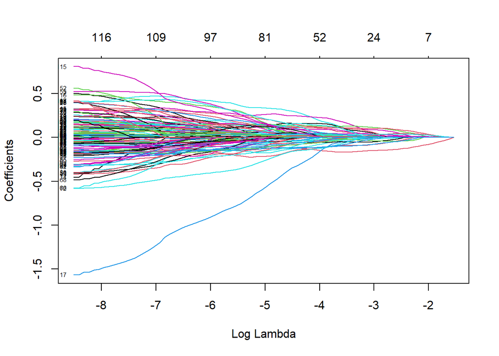

```r
fit_full = lm(BETAPLASMA_log ~ (AGE + QUETELET + FAT + FIBER + CHOLESTEROL + BETADIET + RETDIET +
      I(AGE^2) + I(QUETELET^2) + I(FAT^2) + I(FIBER^2) + I(CHOLESTEROL^2) +
      I(BETADIET^2) + I(RETDIET^2)) *
      (ALCOHOL_Category + SEX + SMOKSTAT + VITUSE),
    data = train_data2)


X <- model.matrix(fit_full)[, -1]
y <- train_data2$BETAPLASMA_log

# Lasso regression
lasso_model <- glmnet(X, y, alpha = 1)
plot(lasso_model, xvar = "lambda", label = TRUE)
```

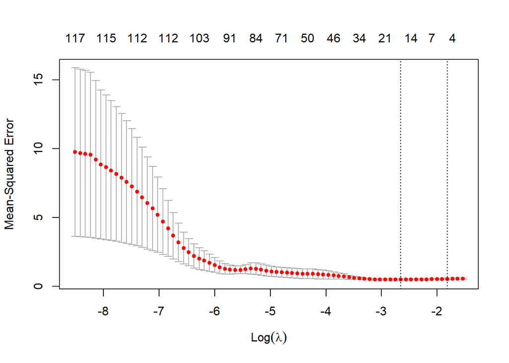

```r
# Perform Cross-Validation to Find Optimal Lambda
set.seed(206)
cv_lasso <- cv.glmnet(X, y, alpha = 1)
best_lambda <- cv_lasso$lambda.min
plot(cv_lasso)
```

```r
# 4.  Fit the Final Model with Optimal Lambda
lasso_final_BETAPLASMA <- glmnet(X, y, alpha = 1, lambda = best_lambda)

# 5. Extract Non-Zero Coefficients
final_coefficients <- coef(lasso_final_BETAPLASMA)
print(final_coefficients)
```

```
## 120 x 1 sparse Matrix of class "dgCMatrix"
##                                                    s0
## (Intercept)                              4.9277999687
## AGE                                      .
## QUETELET                                -0.1374755760
## FAT                                      .
## FIBER                                    .
## CHOLESTEROL                              .
## BETADIET                                 .
## RETDIET                                  .
## I(AGE^2)                                 .
## I(QUETELET^2)                            .
## I(FAT^2)                                 .
## I(FIBER^2)                               .
## I(CHOLESTEROL^2)                        -0.0082411033
## I(BETADIET^2)                            .
## I(RETDIET^2)                             .
## ALCOHOL_CategoryNormal                   .
## ALCOHOL_CategoryHeavy                    .
## SEXMALE                                  .
## SMOKSTATFORMER                           .
## SMOKSTATNEVER                            0.0635078456
## VITUSENOT OFTEN                          .
## VITUSEOFTEN                              0.0038565287
## AGE:ALCOHOL_CategoryNormal               0.0847332089
## AGE:ALCOHOL_CategoryHeavy                .
## AGE:SEXMALE                              .
## AGE:SMOKSTATFORMER                       .
## AGE:SMOKSTATNEVER                        .
## AGE:VITUSENOT OFTEN                      .
## AGE:VITUSEOFTEN                          .
## QUETELET:ALCOHOL_CategoryNormal          .
## QUETELET:ALCOHOL_CategoryHeavy           .
## QUETELET:SEXMALE                         .
## QUETELET:SMOKSTATFORMER                 -0.0218357304
## QUETELET:SMOKSTATNEVER                   .
## QUETELET:VITUSENOT OFTEN                 .
## QUETELET:VITUSEOFTEN                     .
## FAT:ALCOHOL_CategoryNormal               .
## FAT:ALCOHOL_CategoryHeavy                .
```

[output cut: 67 more lines]

```
## I(CHOLESTEROL^2):VITUSEOFTEN             .
## I(BETADIET^2):ALCOHOL_CategoryNormal     0.0008634181
## I(BETADIET^2):ALCOHOL_CategoryHeavy      .
## I(BETADIET^2):SEXMALE                    .
## I(BETADIET^2):SMOKSTATFORMER             .
## I(BETADIET^2):SMOKSTATNEVER              .
## I(BETADIET^2):VITUSENOT OFTEN            .
## I(BETADIET^2):VITUSEOFTEN                .
## I(RETDIET^2):ALCOHOL_CategoryNormal      .
## I(RETDIET^2):ALCOHOL_CategoryHeavy       .
## I(RETDIET^2):SEXMALE                     .
## I(RETDIET^2):SMOKSTATFORMER              .
## I(RETDIET^2):SMOKSTATNEVER               .
## I(RETDIET^2):VITUSENOT OFTEN             .
## I(RETDIET^2):VITUSEOFTEN                 .
```

```r
# 6. Compute Predictions
predictions <- predict(lasso_final_BETAPLASMA, s = best_lambda, newx = X)



nonzero_coef <- coef(lasso_final_BETAPLASMA, s = "lambda.min")
nonzero_coef_df <- as.data.frame(as.matrix(nonzero_coef))
colnames(nonzero_coef_df) <- c("Coefficient")
nonzero_coef_df <- nonzero_coef_df[nonzero_coef_df$Coefficient != 0, , drop = FALSE]
nonzero_coef_df <- cbind(Variable = rownames(nonzero_coef_df), nonzero_coef_df)
rownames(nonzero_coef_df) <- NULL

print(nonzero_coef_df)
```

```
##                                Variable   Coefficient
## 1                           (Intercept)  4.9277999687
## 2                              QUETELET -0.1374755760
## 3                      I(CHOLESTEROL^2) -0.0082411033
## 4                         SMOKSTATNEVER  0.0635078456
## 5                           VITUSEOFTEN  0.0038565287
## 6            AGE:ALCOHOL_CategoryNormal  0.0847332089
## 7               QUETELET:SMOKSTATFORMER -0.0218357304
## 8          FIBER:ALCOHOL_CategoryNormal  0.0272191669
## 9                   FIBER:SMOKSTATNEVER  0.0105453216
## 10                    FIBER:VITUSEOFTEN  0.0149580680
## 11    CHOLESTEROL:ALCOHOL_CategoryHeavy -0.0480156127
## 12                  CHOLESTEROL:SEXMALE -0.0426589783
## 13           CHOLESTEROL:SMOKSTATFORMER -0.0493730270
## 14      BETADIET:ALCOHOL_CategoryNormal  0.0462611474
## 15                 BETADIET:VITUSEOFTEN  0.0969577397
## 16             I(FIBER^2):SMOKSTATNEVER  0.0354067645
## 17 I(BETADIET^2):ALCOHOL_CategoryNormal  0.0008634181
```

```r
# Checking model
ssr <- sum((y - predictions)^2)
ssto <- sum((y - mean(y))^2)
r2 <- 1 - ssr / ssto
cat("R-squared (Training Data):", r2, "\n")
```

```
## R-squared (Training Data): 0.2412949
```

```r
mse <- ssr / (nrow(train_data2) - nrow(nonzero_coef_df))
cat("Mean Squared Error (MSE):", mse, "\n")
```

```
## Mean Squared Error (MSE): 0.4482044
```

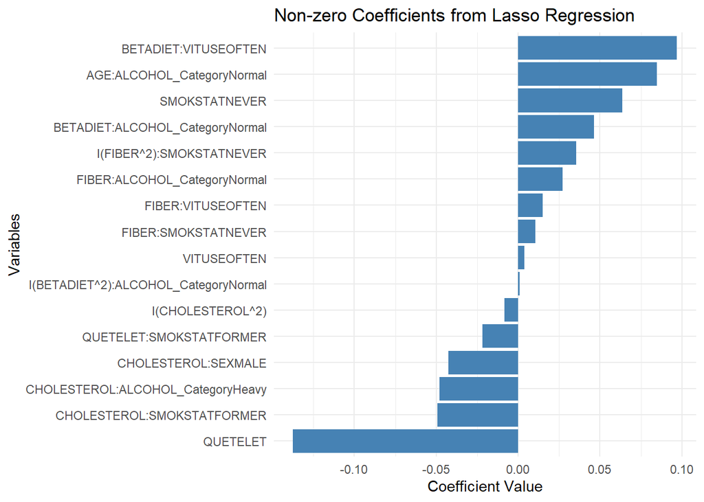

```r
# Remove interaction term
nonzero_coef_df <- nonzero_coef_df[nonzero_coef_df$Variable != "(Intercept)", ]

# plot for coefficient value
ggplot(nonzero_coef_df, aes(x = reorder(Variable, Coefficient), y = Coefficient)) +
  geom_bar(stat = "identity", fill = "steelblue") +
  coord_flip() +
  labs(
    title = "Non-zero Coefficients from Lasso Regression",
    x = "Variables",
    y = "Coefficient Value"
  ) +
  theme_minimal()
```

### 5-1-2. For RETPLASMA_log

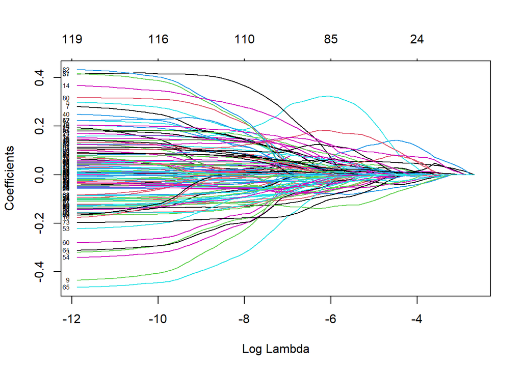

```r
fit_full = lm(RETPLASMA_log ~ (AGE + QUETELET + FAT + FIBER + CHOLESTEROL + BETADIET + RETDIET +
      I(AGE^2) + I(QUETELET^2) + I(FAT^2) + I(FIBER^2) + I(CHOLESTEROL^2) +
      I(BETADIET^2) + I(RETDIET^2)) *
      (ALCOHOL_Category + SEX + SMOKSTAT + VITUSE),
    data = train_data2)



X <- model.matrix(fit_full)[, -1]
y <- train_data2$RETPLASMA_log

# Perform Lasso Regression
lasso_model <- glmnet(X, y, alpha = 1)
plot(lasso_model, xvar = "lambda", label = TRUE)
```

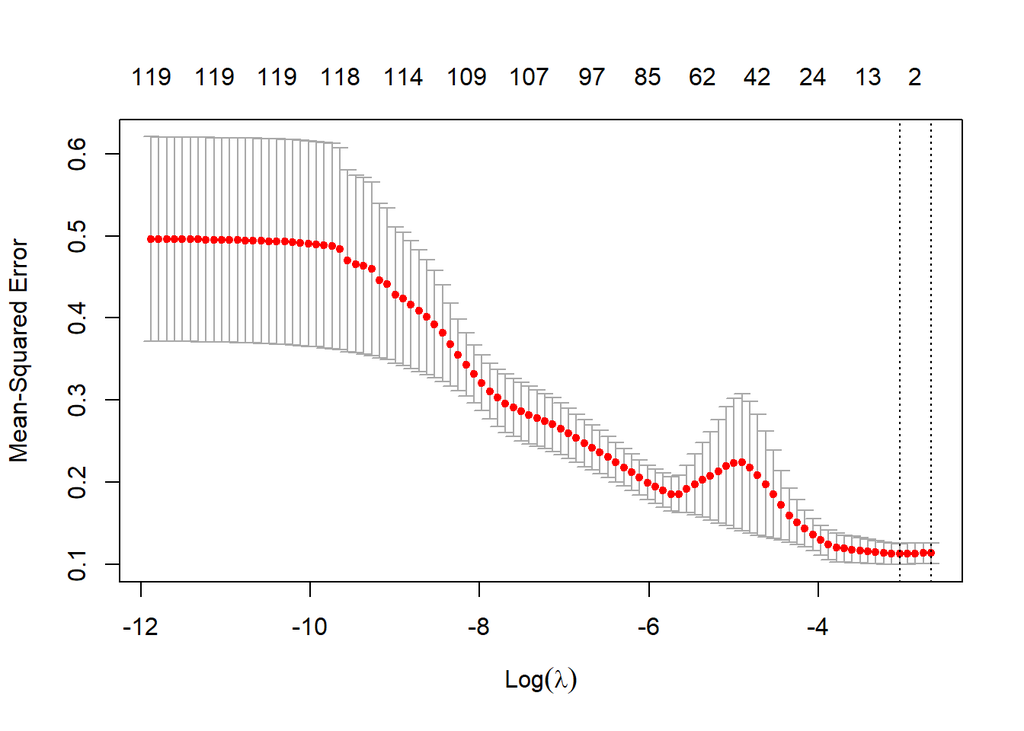

```r
# Perform Cross-Validation to Find Optimal Lambda
set.seed(206)
cv_lasso <- cv.glmnet(X, y, alpha = 1)
best_lambda <- cv_lasso$lambda.min
plot(cv_lasso)
```

```r
# Fit the Final Model with Optimal Lambda
lasso_final_RETPLASMA <- glmnet(X, y, alpha = 1, lambda = best_lambda)

# Extract Non-Zero Coefficients
final_coefficients <- coef(lasso_final_RETPLASMA)  # 提取非零系数
print(final_coefficients)  # 打印结果
```

```
## 120 x 1 sparse Matrix of class "dgCMatrix"
##                                                   s0
## (Intercept)                             6.3466202865
## AGE                                     0.0210518737
## QUETELET                                .
## FAT                                     .
## FIBER                                   .
## CHOLESTEROL                             .
## BETADIET                                .
## RETDIET                                 .
## I(AGE^2)                                .
## I(QUETELET^2)                           .
## I(FAT^2)                                .
## I(FIBER^2)                              .
## I(CHOLESTEROL^2)                        .
## I(BETADIET^2)                           .
## I(RETDIET^2)                            .
## ALCOHOL_CategoryNormal                  .
## ALCOHOL_CategoryHeavy                   0.0337773498
## SEXMALE                                 .
## SMOKSTATFORMER                          .
## SMOKSTATNEVER                           .
## VITUSENOT OFTEN                         .
## VITUSEOFTEN                             .
## AGE:ALCOHOL_CategoryNormal              .
## AGE:ALCOHOL_CategoryHeavy               .
## AGE:SEXMALE                             .
## AGE:SMOKSTATFORMER                      .
## AGE:SMOKSTATNEVER                       .
## AGE:VITUSENOT OFTEN                     .
## AGE:VITUSEOFTEN                         .
## QUETELET:ALCOHOL_CategoryNormal         .
## QUETELET:ALCOHOL_CategoryHeavy          .
## QUETELET:SEXMALE                        .
## QUETELET:SMOKSTATFORMER                 .
## QUETELET:SMOKSTATNEVER                  .
## QUETELET:VITUSENOT OFTEN                .
## QUETELET:VITUSEOFTEN                    .
## FAT:ALCOHOL_CategoryNormal              .
## FAT:ALCOHOL_CategoryHeavy               .
```

[output cut: 67 more lines]

```
## I(CHOLESTEROL^2):VITUSEOFTEN            .
## I(BETADIET^2):ALCOHOL_CategoryNormal    .
## I(BETADIET^2):ALCOHOL_CategoryHeavy     .
## I(BETADIET^2):SEXMALE                   0.0101490638
## I(BETADIET^2):SMOKSTATFORMER            0.0002586179
## I(BETADIET^2):SMOKSTATNEVER             .
## I(BETADIET^2):VITUSENOT OFTEN           .
## I(BETADIET^2):VITUSEOFTEN               .
## I(RETDIET^2):ALCOHOL_CategoryNormal     .
## I(RETDIET^2):ALCOHOL_CategoryHeavy      .
## I(RETDIET^2):SEXMALE                    .
## I(RETDIET^2):SMOKSTATFORMER             .
## I(RETDIET^2):SMOKSTATNEVER              .
## I(RETDIET^2):VITUSENOT OFTEN            .
## I(RETDIET^2):VITUSEOFTEN                .
```

```r
# Prediction
predictions <- predict(lasso_final_RETPLASMA, s = best_lambda, newx = X)


nonzero_coef <- coef(lasso_final_RETPLASMA, s = "lambda.min")
nonzero_coef_df <- as.data.frame(as.matrix(nonzero_coef))
colnames(nonzero_coef_df) <- c("Coefficient")
nonzero_coef_df <- nonzero_coef_df[nonzero_coef_df$Coefficient != 0, , drop = FALSE]
nonzero_coef_df <- cbind(Variable = rownames(nonzero_coef_df), nonzero_coef_df)
rownames(nonzero_coef_df) <- NULL

print(nonzero_coef_df)
```

```
##                              Variable  Coefficient
## 1                         (Intercept) 6.3466202865
## 2                                 AGE 0.0210518737
## 3               ALCOHOL_CategoryHeavy 0.0337773498
## 4 I(QUETELET^2):ALCOHOL_CategoryHeavy 0.0122109227
## 5               I(BETADIET^2):SEXMALE 0.0101490638
## 6        I(BETADIET^2):SMOKSTATFORMER 0.0002586179
```

```r
# Checking model
ssr <- sum((y - predictions)^2)
ssto <- sum((y - mean(y))^2)
r2 <- 1 - ssr / ssto
cat("R-squared (Training Data):", r2, "\n")
```

```
## R-squared (Training Data): 0.04105071
```

```r
mse <- ssr / (nrow(train_data2) - nrow(nonzero_coef_df))
cat("Mean Squared Error (MSE):", mse, "\n")
```

```
## Mean Squared Error (MSE): 0.1105255
```

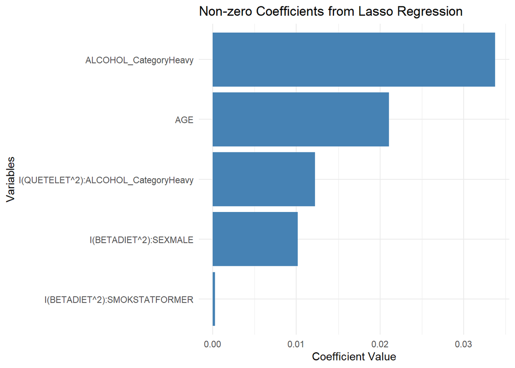

```r
nonzero_coef_df <- nonzero_coef_df[nonzero_coef_df$Variable != "(Intercept)", ]

ggplot(nonzero_coef_df, aes(x = reorder(Variable, Coefficient), y = Coefficient)) +
  geom_bar(stat = "identity", fill = "steelblue") +
  coord_flip() +
  labs(
    title = "Non-zero Coefficients from Lasso Regression",
    x = "Variables",
    y = "Coefficient Value"
  ) +
  theme_minimal()
```